# Data Preprocessing

Yang Liao

2023-10-02

# Tutorial for data preprocessing

In DMLA cycle, ‘D’ represents discover, i.e. experimental discovery of special biological response that can be captured by meta-omics datasets. ‘M’ represents model, i.e. utilizing biological domain-knowledge integrated models to characterize complex biological process.

In this tutorial, we demonstrate the preprocess of raw datasets, i.e. the ‘D’ stage in DMLA cycle, to obtain basic information and datasets for geometric deep leanring, i.e. the ‘M’ stage.

We start by define the dataset name, as well as paths for expression levels/abundance and annotations. After that, we conduct DESeq analysis to obtain DEGs (Differentially Expressed Genes) through obtain_DEGs(). After that, we obtain the datasets (dgi dataset) for geometric deep learning and graph data based on TSNE analysis, i.e. get_tsne_df(). This function returns graph_data_list, a list that contain graph datasets and dgi datasets.

The following DEMOs are based on different datasets.

## DEMO1: Optogenetic denitrifier based on metatranscriptomics

### ‘D’: Discover – Data preprocessing

- After run the cell once, file will be saved and the next run will not conduct DESeq analysis again. Instead, read the DESeq results from local saved files directly.
- TIPS: make sure to set appropriate filtering threshold of expression level or abundance for gene filtering. This depeneds on the number of samples. Generally, 0.1*N is a good threshold (N is the number of sample.)
- The original cell output is as follows:

```
[1] "The total number of DEGs (not unique): 109276"
[1] "The total number of unique DEGs (not unique): 55189"
[1] "The total number of deseq filtered DEGs: 42666"
[1] "The total number of unique deseq filtered DEGs: 37217"
[1] "The number of total genes (unique): 56991"
[1] "The number of total DEGs after filtering : 29643"

  Blue_vs_Dark Yellow_vs_Dark
         25277           4366
[1] "The total number of unique DEGs for tsne analysis of Blue_vs_Dark dataset is: 25277"
[1] "The total number of unique DEGs for tsne analysis of Yellow_vs_Dark dataset is: 4366"
```

```r
rm(list=ls())

# load function
source('./scr/R/PreprocessingFunctions.R')

# === import data path ===
# --- DESeq ---
dataset <- 'LY_9samples_metatranscriptomics'
rawdata_path <- paste("./data/", dataset, "/rawdata/reads_number.txt", sep = '')
group_path <- paste("./data/", dataset, "/inputdata/group.csv", sep = '')
output_path <- paste("./data/", dataset, "/inputdata/", sep = '') # input data for modeling in python
output_path.rawDEGs <- paste(output_path, 'DEGs_raw.csv', sep = '')

# --- filtered DEGs ---
rpkm_path <- paste("./data/", dataset, "/rawdata/RPKM.txt", sep = '')
DEGs.filtered.path <- paste("./data/", dataset, "/inputdata/DEGs_filtered.csv", sep = '')

## subcellular annotation
anno.signal <- paste("./data/", dataset, "/rawdata/Signal.csv", sep = '')
anno.tmhmm <- paste("./data/", dataset, "/rawdata/tmhmm.csv", sep = '')

# === conduct analysis ===
# obtain DEGs
DEGs.filtered <- obtain_DEGs(rawdata_path, group_path,
                        rpkm_path, thre = 1,
                        output_path.rawDEGs, DEGs.filtered.path)
```

```
## [1] "File ./data/LY_9samples_metatranscriptomics/inputdata/DEGs_raw.csv exists."
## [1] "File ./data/LY_9samples_metatranscriptomics/inputdata/DEGs_filtered.csv exists."
```

```r
# obtain graph data
graph_data_list <- get_tsne_df(DEGs.filtered, dataset,
                               group_path,
                               anno.info.1=anno.signal,
                               anno.info.2=anno.tmhmm)
```

```
## [1] "File ./data/LY_9samples_metatranscriptomics/inputdata/graphdata_Blue_vs_Dark.csv exists and successfully load."
## [1] "File ./data/LY_9samples_metatranscriptomics/inputdata/graphdata_Yellow_vs_Dark.csv exists and successfully load."
```

Here is a visualization toul for dataset exploratory analysis. For example, the distribution of subcellular information among all genes.

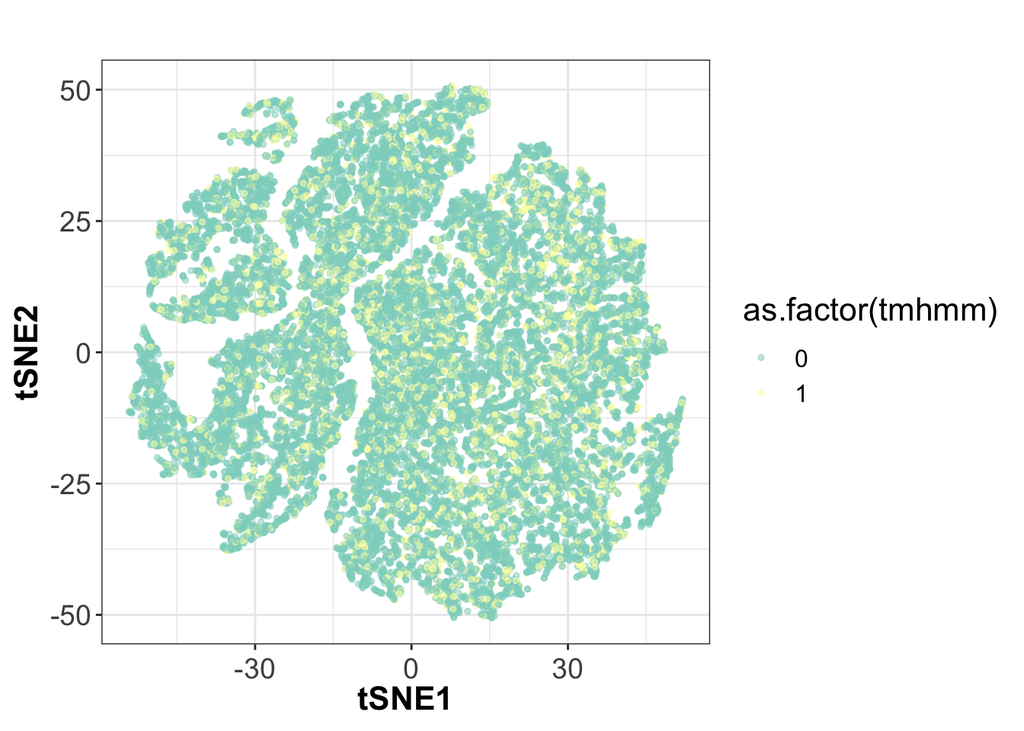

```r
# ========= visualization toolkits =========

# ---  tsne plot ---
graph_data <- graph_data_list$Blue_vs_Dark
ggplot(graph_data,aes(tSNE1,tSNE2, colour = as.factor(tmhmm))) +  # ,colour = degs
  geom_point(alpha = 0.5, size = 1) +
  labs(title = '') +
  theme_bw() +
  scale_colour_manual(values = pale_25) +
  mytheme1
```

### ‘M’: Model - Geometric deep learning through DGL algorithm

In this part, we utilized geomteric deep learning to unsupervised learned the genetic co-expression, i.e. obtaining gene panels.

The obtained gene panels’ labels are stored at ‘generated_data/types.txt’

```bash
cd ./scr
source /Users/yangliao/opt/anaconda3/bin/activate pyg # directory to your local activate path. You can figure out your path through command 'which activate' in your terminal; pyg: the name of your virtual environment

#!/bin/sh
dataset_name='LY_9samples_metatranscriptomics' # dataset
group='Yellow_vs_Dark' # subdataset
threshold=0.4 # threshold for edge construction
epoch=20000 # trainnning epoches

## To run graph learning, un-annotated the following commands:
# python3 -c "import main; main.set_config('$dataset_name', '$group', thre=$threshold, num_epoch=$epoch); print(main.config['data_path']); main.main()"
```

- The output of above cell is as follow

```
../data/LY_9samples_metatranscriptomics/inputdata/dgidata_Yellow_vs_Dark.csv
feature shape:  (6, 4366)
cuda is not available
Threshold: 0.4
 Links number: 120788
 Average Links: 27.665597801191023
Adj: (4366, 4366) Edges: 120788
X: (4366, 6)
Adj: (4366, 4366) Edges: 120788
X: (4366, 6)
-----------Deep Graph Infomax-------------
Epoch: 100, Loss: 1.3740
Epoch: 200, Loss: 1.3624
Epoch: 300, Loss: 1.3524
Epoch: 400, Loss: 1.3429
Epoch: 500, Loss: 1.3308
Epoch: 600, Loss: 1.3212
Epoch: 700, Loss: 1.3067
Epoch: 800, Loss: 1.2914
Epoch: 900, Loss: 1.2738
Epoch: 1000, Loss: 1.2576
Epoch: 1100, Loss: 1.2347
Epoch: 1200, Loss: 1.2201
Epoch: 1300, Loss: 1.1943
Epoch: 1400, Loss: 1.1716
Epoch: 1500, Loss: 1.1600
Epoch: 1600, Loss: 1.1363
Epoch: 1700, Loss: 1.1074
Epoch: 1800, Loss: 1.0961
Epoch: 1900, Loss: 1.0590
Epoch: 2000, Loss: 1.0428
Epoch: 2100, Loss: 1.0312
Epoch: 2200, Loss: 0.9945
Epoch: 2300, Loss: 0.9611
Epoch: 2400, Loss: 0.9420
Epoch: 2500, Loss: 0.9062
Epoch: 2600, Loss: 0.8841
Epoch: 2700, Loss: 0.8591
Epoch: 2800, Loss: 0.8617
Epoch: 2900, Loss: 0.8160
Epoch: 3000, Loss: 0.8136
Epoch: 3100, Loss: 0.7851
Epoch: 3200, Loss: 0.7635
Epoch: 3300, Loss: 0.7412
Epoch: 3400, Loss: 0.7442
Epoch: 3500, Loss: 0.7015
Epoch: 3600, Loss: 0.6864
Epoch: 3700, Loss: 0.6676
Epoch: 3800, Loss: 0.6705
Epoch: 3900, Loss: 0.6456
Epoch: 4000, Loss: 0.6152
Epoch: 4100, Loss: 0.6124
Epoch: 4200, Loss: 0.5935
Epoch: 4300, Loss: 0.6069
Epoch: 4400, Loss: 0.5489
Epoch: 4500, Loss: 0.5659
Epoch: 4600, Loss: 0.5373
Epoch: 4700, Loss: 0.5481
Epoch: 4800, Loss: 0.5533
Epoch: 4900, Loss: 0.5120
Epoch: 5000, Loss: 0.4894
Epoch: 5100, Loss: 0.4968
Epoch: 5200, Loss: 0.4605
Epoch: 5300, Loss: 0.4762
Epoch: 5400, Loss: 0.4904
Epoch: 5500, Loss: 0.4601
Epoch: 5600, Loss: 0.4143
Epoch: 5700, Loss: 0.4042
Epoch: 5800, Loss: 0.4367
Epoch: 5900, Loss: 0.4085
Epoch: 6000, Loss: 0.4195
Epoch: 6100, Loss: 0.3963
Epoch: 6200, Loss: 0.3600
Epoch: 6300, Loss: 0.3902
Epoch: 6400, Loss: 0.3678
Epoch: 6500, Loss: 0.3862
Epoch: 6600, Loss: 0.3768
Epoch: 6700, Loss: 0.3662
Epoch: 6800, Loss: 0.3478
Epoch: 6900, Loss: 0.3377
Epoch: 7000, Loss: 0.3226
Epoch: 7100, Loss: 0.3438
Epoch: 7200, Loss: 0.3092
Epoch: 7300, Loss: 0.3024
Epoch: 7400, Loss: 0.3136
Epoch: 7500, Loss: 0.2969
Epoch: 7600, Loss: 0.3063
Epoch: 7700, Loss: 0.3253
Epoch: 7800, Loss: 0.2950
Epoch: 7900, Loss: 0.3053
Epoch: 8000, Loss: 0.3180
Epoch: 8100, Loss: 0.2683
Epoch: 8200, Loss: 0.2863
Epoch: 8300, Loss: 0.2949
Epoch: 8400, Loss: 0.2615
Epoch: 8500, Loss: 0.2510
Epoch: 8600, Loss: 0.2950
Epoch: 8700, Loss: 0.2628
Epoch: 8800, Loss: 0.2767
Epoch: 8900, Loss: 0.2600
Epoch: 9000, Loss: 0.2378
Epoch: 9100, Loss: 0.2540
Epoch: 9200, Loss: 0.2324
Epoch: 9300, Loss: 0.2312
Epoch: 9400, Loss: 0.2264
Epoch: 9500, Loss: 0.2336
Epoch: 9600, Loss: 0.2056
Epoch: 9700, Loss: 0.1881
Epoch: 9800, Loss: 0.2365
Epoch: 9900, Loss: 0.2022
Epoch: 10000, Loss: 0.2174
Epoch: 10100, Loss: 0.2291
Epoch: 10200, Loss: 0.2285
Epoch: 10300, Loss: 0.2191
Epoch: 10400, Loss: 0.2314
Epoch: 10500, Loss: 0.2056
Epoch: 10600, Loss: 0.2030
Epoch: 10700, Loss: 0.2579
Epoch: 10800, Loss: 0.1740
Epoch: 10900, Loss: 0.1893
Epoch: 11000, Loss: 0.1859
Epoch: 11100, Loss: 0.2140
Epoch: 11200, Loss: 0.1787
Epoch: 11300, Loss: 0.2078
Epoch: 11400, Loss: 0.2035
Epoch: 11500, Loss: 0.2189
Epoch: 11600, Loss: 0.1960
Epoch: 11700, Loss: 0.2005
Epoch: 11800, Loss: 0.1624
Epoch: 11900, Loss: 0.1805
Epoch: 12000, Loss: 0.2185
Epoch: 12100, Loss: 0.1832
Epoch: 12200, Loss: 0.2157
Epoch: 12300, Loss: 0.1595
Epoch: 12400, Loss: 0.1507
Epoch: 12500, Loss: 0.1800
Epoch: 12600, Loss: 0.1856
Epoch: 12700, Loss: 0.1630
Epoch: 12800, Loss: 0.1661
Epoch: 12900, Loss: 0.1759
Epoch: 13000, Loss: 0.2176
Epoch: 13100, Loss: 0.1659
Epoch: 13200, Loss: 0.1661
Epoch: 13300, Loss: 0.1938
Epoch: 13400, Loss: 0.1717
Epoch: 13500, Loss: 0.1687
Epoch: 13600, Loss: 0.1472
Epoch: 13700, Loss: 0.2006
Epoch: 13800, Loss: 0.1628
Epoch: 13900, Loss: 0.1472
Epoch: 14000, Loss: 0.1773
Epoch: 14100, Loss: 0.1287
Epoch: 14200, Loss: 0.1716
Epoch: 14300, Loss: 0.2194
Epoch: 14400, Loss: 0.1793
Epoch: 14500, Loss: 0.1452
Epoch: 14600, Loss: 0.1313
Epoch: 14700, Loss: 0.1943
Epoch: 14800, Loss: 0.1503
Epoch: 14900, Loss: 0.1642
Epoch: 15000, Loss: 0.1476
Epoch: 15100, Loss: 0.1426
Epoch: 15200, Loss: 0.1532
Epoch: 15300, Loss: 0.1530
Epoch: 15400, Loss: 0.1402
Epoch: 15500, Loss: 0.1900
Epoch: 15600, Loss: 0.1534
Epoch: 15700, Loss: 0.1401
Epoch: 15800, Loss: 0.1666
Epoch: 15900, Loss: 0.1569
Epoch: 16000, Loss: 0.1374
Epoch: 16100, Loss: 0.1777
Epoch: 16200, Loss: 0.1427
Epoch: 16300, Loss: 0.1573
Epoch: 16400, Loss: 0.1844
Epoch: 16500, Loss: 0.1406
Epoch: 16600, Loss: 0.1649
Epoch: 16700, Loss: 0.1528
Epoch: 16800, Loss: 0.1279
Epoch: 16900, Loss: 0.1688
Epoch: 17000, Loss: 0.1596
Epoch: 17100, Loss: 0.1576
Epoch: 17200, Loss: 0.1478
Epoch: 17300, Loss: 0.1337
Epoch: 17400, Loss: 0.1512
Epoch: 17500, Loss: 0.1652
Epoch: 17600, Loss: 0.1366
Epoch: 17700, Loss: 0.1506
Epoch: 17800, Loss: 0.1575
Epoch: 17900, Loss: 0.1456
Epoch: 18000, Loss: 0.1606
Epoch: 18100, Loss: 0.1311
Epoch: 18200, Loss: 0.1636
Epoch: 18300, Loss: 0.1707
Epoch: 18400, Loss: 0.1784
Epoch: 18500, Loss: 0.1366
Epoch: 18600, Loss: 0.1296
Epoch: 18700, Loss: 0.1685
Epoch: 18800, Loss: 0.1431
Epoch: 18900, Loss: 0.1335
Epoch: 19000, Loss: 0.1544
Epoch: 19100, Loss: 0.1308
Epoch: 19200, Loss: 0.1309
Epoch: 19300, Loss: 0.1382
Epoch: 19400, Loss: 0.1576
Epoch: 19500, Loss: 0.1457
Epoch: 19600, Loss: 0.1465
Epoch: 19700, Loss: 0.1467
Epoch: 19800, Loss: 0.1932
Epoch: 19900, Loss: 0.1394
Epoch: 20000, Loss: 0.1440
Training time in seconds:  8688
-----------Clustering-------------
Shape of data to PCA: (4366, 256)
Shape of data output by PCA: (4366, 30)
PCA recover: 0.9999489
Shape of data to cluster: (4366, 30)
SCI score (Clustering quality) is: 0.6379427
```

## DEMO2: Optogenetic anaerobic CO2 fixation for denitrification based on metatranscriptomics

### ‘D’: Discover

- The original output is as follows:

[output not shown]

```
[1] "The total number of DEGs (not unique): 363440"
[1] "The total number of unique DEGs (not unique): 122309"
[1] "The total number of deseq filtered DEGs: 208061"
[1] "The total number of unique deseq filtered DEGs: 95944"
[1] "The number of total genes (unique): 204424"
[1] "The number of total DEGs after filtering : 66857"

  Blue_vs_White    Red_vs_White Yellow_vs_White
          21744           21741           23372
[1] "The total number of unique DEGs for tsne analysis of Blue_vs_White dataset is: 21744"
[1] "The total number of unique DEGs for tsne analysis of Red_vs_White dataset is: 21741"
[1] "The total number of unique DEGs for tsne analysis of Yellow_vs_White dataset is: 23372"
```

```r
rm(list=ls())

# load function
source('./scr/R/PreprocessingFunctions.R')

# === import data path ===
# --- DESeq ---
dataset <- 'ZJ_12samples_metatranscriptomics'
rawdata_path <- paste("./data/", dataset, "/rawdata/reads_number.txt", sep = '')
group_path <- paste("./data/", dataset, "/inputdata/group.csv", sep = '')
output_path <- paste("./data/", dataset, "/inputdata/", sep = '') # input data for modeling in python
output_path.rawDEGs <- paste(output_path, 'DEGs_raw.csv', sep = '')

# --- filtered DEGs ---
rpkm_path <- paste("./data/", dataset, "/rawdata/RPKM.txt", sep = '')
DEGs.filtered.path <- paste("./data/", dataset, "/inputdata/DEGs_filtered.csv", sep = '')

## subcellular annotation
anno.signal <- paste("./data/", dataset, "/rawdata/Signal.csv", sep = '')
anno.tmhmm <- paste("./data/", dataset, "/rawdata/tmhmm.csv", sep = '')

# === conduct analysis ===
# obtain DEGs (padj for metatranscriptomics)
DEGs.filtered <- obtain_DEGs(rawdata_path, group_path,
                        rpkm_path, thre = 6,
                        output_path.rawDEGs, DEGs.filtered.path)
```

```
## [1] "File ./data/ZJ_12samples_metatranscriptomics/inputdata/DEGs_raw.csv exists."
## [1] "File ./data/ZJ_12samples_metatranscriptomics/inputdata/DEGs_filtered.csv exists."
```

```r
# obtain graph data
# umap can also be adopted to allieviate the duplication problem arounsed by tsne
graph_data_list <- reduce_df(DEGs.filtered, dataset,
                             anno.info.1=anno.signal,
                             anno.info.2=anno.tmhmm,
                             group_path, perplex=50,
                             Reduction= 'umap',
                             normalization='stand')
```

```
## [1] "File ./data/ZJ_12samples_metatranscriptomics/inputdata/graphdata_Blue_vs_White.csv exists and successfully load."
## [1] "File ./data/ZJ_12samples_metatranscriptomics/inputdata/graphdata_Red_vs_White.csv exists and successfully load."
## [1] "File ./data/ZJ_12samples_metatranscriptomics/inputdata/graphdata_Yellow_vs_White.csv exists and successfully load."
```

### ‘M’: Model - Geometric deep learning through DGL algorithm

```bash
cd ./scr
source /Users/yangliao/opt/anaconda3/bin/activate pyg
# conda activate pyg

#!/bin/sh
dataset_name='ZJ_12samples_metatranscriptomics' # dataset
group='Blue_vs_White' # subdataset
threshold=0.4 # threshold for edge construction
epoch=20000 # trainnning epoches

# # To run graph learning, un-annotated the following commands:
# python3 -c "import main; main.set_config('$dataset_name', '$group', thre=$threshold, num_epoch=$epoch); print(main.config['data_path']); main.main()"
```

[output not shown]

[output cut: 62 more lines]

```
Epoch: 9300, Loss: 0.3110
Epoch: 9400, Loss: 0.3077
Epoch: 9500, Loss: 0.3038
Epoch: 9600, Loss: 0.3011
Epoch: 9700, Loss: 0.2953
Epoch: 9800, Loss: 0.2930
Epoch: 9900, Loss: 0.2873
Epoch: 10000, Loss: 0.2901
Training time in seconds:  674
-----------Clustering-------------
Shape of data to PCA: (21744, 256)
Shape of data output by PCA: (21744, 30)
PCA recover: 0.99897283
Shape of data to cluster: (21744, 30)
SCI score (Clustering quality) is: 0.35338965
```

## DEMO3: Optogenetic denitrifier based on metagenomics

### ‘D’: Discover

- The original cell output is as follows:

```
[1] "The total number of DEGs (not unique): 788036"
[1] "The total number of unique DEGs (not unique): 197009"
[1] "The total number of deseq filtered DEGs: 15157"
[1] "The total number of unique deseq filtered DEGs: 12021"
[1] "The number of total genes (unique): 198113"
[1] "The number of total DEGs after filtering : 922"

  Blue_vs_Dark  Green_vs_Dark    Red_vs_Dark Yellow_vs_Dark
            88            135            642             57
[1] "The total number of unique DEGs for tsne analysis of Blue_vs_Dark dataset is: 88"
[1] "The total number of unique DEGs for tsne analysis of Green_vs_Dark dataset is: 135"
[1] "The total number of unique DEGs for tsne analysis of Red_vs_Dark dataset is: 642"
[1] "The total number of unique DEGs for tsne analysis of Yellow_vs_Dark dataset is: 57"
```

```r
rm(list=ls())
source('./scr/R/PreprocessingFunctions.R')

# === import data path ===
# --- DESeq ---
dataset <- 'LY_15samples_metagenomics'
rawdata_path <- paste("./data/", dataset, "/rawdata/reads_number.txt", sep = '')
group_path <- paste("./data/", dataset, "/inputdata/group.csv", sep = '')
output_path <- paste("./data/", dataset, "/inputdata/", sep = '') # input data for modeling in python
output_path.rawDEGs <- paste(output_path, 'DEGs_raw.csv', sep = '')

# --- filtered DEGs ---
rpkm_path <- paste("./data/", dataset, "/rawdata/RPKM.txt", sep = '')
DEGs.filtered.path <- paste("./data/", dataset, "/inputdata/DEGs_filtered.csv", sep = '')

## subcellular annotation
anno.signal <- paste("./data/", dataset, "/rawdata/Signal.csv", sep = '')
anno.tmhmm <- paste("./data/", dataset, "/rawdata/tmhmm.csv", sep = '')

# === conduct analysis ===
# obtain DEGs
DEGs.filtered <- obtain_DEGs(rawdata_path, group_path,
                             rpkm_path, thre = 1,
                             output_path.rawDEGs,
                             DEGs.filtered.path)
```

```
## [1] "File ./data/LY_15samples_metagenomics/inputdata/DEGs_raw.csv exists."
## [1] "File ./data/LY_15samples_metagenomics/inputdata/DEGs_filtered.csv exists."
```

```r
# obtain graph data
graph_data_list <- get_tsne_df(DEGs.filtered, dataset,
                               group_path, perplex = 10)
```

```
## [1] "File ./data/LY_15samples_metagenomics/inputdata/graphdata_Blue_vs_Dark.csv exists and successfully load."
## [1] "File ./data/LY_15samples_metagenomics/inputdata/graphdata_Green_vs_Dark.csv exists and successfully load."
## [1] "File ./data/LY_15samples_metagenomics/inputdata/graphdata_Red_vs_Dark.csv exists and successfully load."
## [1] "File ./data/LY_15samples_metagenomics/inputdata/graphdata_Yellow_vs_Dark.csv exists and successfully load."
```

### ‘M’: Model - Geometric deep learning through DGL algorithm

```bash
cd ./scr
source /Users/yangliao/opt/anaconda3/bin/activate pyg
# conda activate pyg

#!/bin/sh
dataset_name='LY_15samples_metagenomics' # dataset
group='Blue_vs_Dark' # subdataset
threshold=0.4 # threshold for edge construction
epoch=20000 # trainnning epoches

# # To run graph learning, un-annotated the following commands:
# python3 -c "import main; main.set_config('$dataset_name', '$group', thre=$threshold, num_epoch=$epoch); print(main.config['data_path']); main.main()"
```

[output not shown]

- The output of above cell is as follow(group=‘Blue_vs_Dark’:

```
../data/LY_15samples_metagenomics/inputdata/dgidata_Blue_vs_Dark.csv
feature shape:  (5, 88)
cuda is not available
Threshold: 0.4
 Links number: 276
 Average Links: 3.1363636363636362
Adj: (88, 88) Edges: 276
X: (88, 5)
Adj: (88, 88) Edges: 276
X: (88, 5)
-----------Deep Graph Infomax-------------
Epoch: 100, Loss: 1.3858
Epoch: 200, Loss: 1.3845
Epoch: 300, Loss: 1.3836
Epoch: 400, Loss: 1.3845
Epoch: 500, Loss: 1.3834
Epoch: 600, Loss: 1.3825
Epoch: 700, Loss: 1.3813
Epoch: 800, Loss: 1.3807
Epoch: 900, Loss: 1.3820
Epoch: 1000, Loss: 1.3820
Epoch: 1100, Loss: 1.3796
Epoch: 1200, Loss: 1.3803
Epoch: 1300, Loss: 1.3795
Epoch: 1400, Loss: 1.3795
Epoch: 1500, Loss: 1.3780
Epoch: 1600, Loss: 1.3771
Epoch: 1700, Loss: 1.3760
Epoch: 1800, Loss: 1.3740
Epoch: 1900, Loss: 1.3754
Epoch: 2000, Loss: 1.3745
Epoch: 2100, Loss: 1.3752
Epoch: 2200, Loss: 1.3722
Epoch: 2300, Loss: 1.3706
Epoch: 2400, Loss: 1.3706
Epoch: 2500, Loss: 1.3718
Epoch: 2600, Loss: 1.3700
Epoch: 2700, Loss: 1.3704
Epoch: 2800, Loss: 1.3665
Epoch: 2900, Loss: 1.3683
Epoch: 3000, Loss: 1.3711
Epoch: 3100, Loss: 1.3702
Epoch: 3200, Loss: 1.3687
Epoch: 3300, Loss: 1.3588
Epoch: 3400, Loss: 1.3581
Epoch: 3500, Loss: 1.3692
Epoch: 3600, Loss: 1.3510
Epoch: 3700, Loss: 1.3654
Epoch: 3800, Loss: 1.3526
Epoch: 3900, Loss: 1.3631
Epoch: 4000, Loss: 1.3558
Epoch: 4100, Loss: 1.3508
Epoch: 4200, Loss: 1.3500
Epoch: 4300, Loss: 1.3584
Epoch: 4400, Loss: 1.3492
Epoch: 4500, Loss: 1.3454
Epoch: 4600, Loss: 1.3469
Epoch: 4700, Loss: 1.3476
Epoch: 4800, Loss: 1.3386
Epoch: 4900, Loss: 1.3367
Epoch: 5000, Loss: 1.3301
Epoch: 5100, Loss: 1.3500
Epoch: 5200, Loss: 1.3322
Epoch: 5300, Loss: 1.3441
Epoch: 5400, Loss: 1.3126
Epoch: 5500, Loss: 1.3391
Epoch: 5600, Loss: 1.3130
Epoch: 5700, Loss: 1.3136
Epoch: 5800, Loss: 1.3307
Epoch: 5900, Loss: 1.3195
Epoch: 6000, Loss: 1.3228
Epoch: 6100, Loss: 1.3346
Epoch: 6200, Loss: 1.3285
Epoch: 6300, Loss: 1.3070
Epoch: 6400, Loss: 1.3239
Epoch: 6500, Loss: 1.3026
Epoch: 6600, Loss: 1.3195
Epoch: 6700, Loss: 1.3458
Epoch: 6800, Loss: 1.3062
Epoch: 6900, Loss: 1.3207
Epoch: 7000, Loss: 1.3353
Epoch: 7100, Loss: 1.3172
Epoch: 7200, Loss: 1.3385
Epoch: 7300, Loss: 1.3411
Epoch: 7400, Loss: 1.3063
Epoch: 7500, Loss: 1.2792
Epoch: 7600, Loss: 1.3300
Epoch: 7700, Loss: 1.2961
Epoch: 7800, Loss: 1.2842
Epoch: 7900, Loss: 1.2712
Epoch: 8000, Loss: 1.3400
Epoch: 8100, Loss: 1.2962
Epoch: 8200, Loss: 1.2852
Epoch: 8300, Loss: 1.2815
Epoch: 8400, Loss: 1.2915
Epoch: 8500, Loss: 1.2758
Epoch: 8600, Loss: 1.2940
Epoch: 8700, Loss: 1.3013
Epoch: 8800, Loss: 1.2481
Epoch: 8900, Loss: 1.2742
Epoch: 9000, Loss: 1.2925
Epoch: 9100, Loss: 1.3005
Epoch: 9200, Loss: 1.2725
Epoch: 9300, Loss: 1.2465
Epoch: 9400, Loss: 1.2485
Epoch: 9500, Loss: 1.2468
Epoch: 9600, Loss: 1.2883
Epoch: 9700, Loss: 1.2785
Epoch: 9800, Loss: 1.2463
Epoch: 9900, Loss: 1.2559
Epoch: 10000, Loss: 1.2582
Epoch: 10100, Loss: 1.2881
Epoch: 10200, Loss: 1.2559
Epoch: 10300, Loss: 1.2536
Epoch: 10400, Loss: 1.2168
Epoch: 10500, Loss: 1.2827
Epoch: 10600, Loss: 1.3091
Epoch: 10700, Loss: 1.2432
Epoch: 10800, Loss: 1.2988
Epoch: 10900, Loss: 1.2846
Epoch: 11000, Loss: 1.2243
Epoch: 11100, Loss: 1.2490
Epoch: 11200, Loss: 1.2422
Epoch: 11300, Loss: 1.2346
Epoch: 11400, Loss: 1.2655
Epoch: 11500, Loss: 1.2407
Epoch: 11600, Loss: 1.2277
Epoch: 11700, Loss: 1.2015
Epoch: 11800, Loss: 1.2527
Epoch: 11900, Loss: 1.2583
Epoch: 12000, Loss: 1.2060
Epoch: 12100, Loss: 1.2675
Epoch: 12200, Loss: 1.2562
Epoch: 12300, Loss: 1.2777
Epoch: 12400, Loss: 1.2252
Epoch: 12500, Loss: 1.2327
Epoch: 12600, Loss: 1.2405
Epoch: 12700, Loss: 1.1854
Epoch: 12800, Loss: 1.2222
Epoch: 12900, Loss: 1.2559
Epoch: 13000, Loss: 1.2618
Epoch: 13100, Loss: 1.2641
Epoch: 13200, Loss: 1.2471
Epoch: 13300, Loss: 1.2049
Epoch: 13400, Loss: 1.2131
Epoch: 13500, Loss: 1.2429
Epoch: 13600, Loss: 1.2310
Epoch: 13700, Loss: 1.2325
Epoch: 13800, Loss: 1.1933
Epoch: 13900, Loss: 1.1430
Epoch: 14000, Loss: 1.2626
Epoch: 14100, Loss: 1.1966
Epoch: 14200, Loss: 1.2480
Epoch: 14300, Loss: 1.1913
Epoch: 14400, Loss: 1.2269
Epoch: 14500, Loss: 1.1767
Epoch: 14600, Loss: 1.1576
Epoch: 14700, Loss: 1.2584
Epoch: 14800, Loss: 1.1991
Epoch: 14900, Loss: 1.1787
Epoch: 15000, Loss: 1.2020
Epoch: 15100, Loss: 1.1806
Epoch: 15200, Loss: 1.2089
Epoch: 15300, Loss: 1.2503
Epoch: 15400, Loss: 1.2282
Epoch: 15500, Loss: 1.1743
Epoch: 15600, Loss: 1.1754
Epoch: 15700, Loss: 1.2143
Epoch: 15800, Loss: 1.2288
Epoch: 15900, Loss: 1.2139
Epoch: 16000, Loss: 1.2678
Epoch: 16100, Loss: 1.2408
Epoch: 16200, Loss: 1.1607
Epoch: 16300, Loss: 1.1783
Epoch: 16400, Loss: 1.1615
Epoch: 16500, Loss: 1.1472
Epoch: 16600, Loss: 1.2128
Epoch: 16700, Loss: 1.1640
Epoch: 16800, Loss: 1.1699
Epoch: 16900, Loss: 1.1746
Epoch: 17000, Loss: 1.1463
Epoch: 17100, Loss: 1.2274
Epoch: 17200, Loss: 1.2229
Epoch: 17300, Loss: 1.2488
Epoch: 17400, Loss: 1.1528
Epoch: 17500, Loss: 1.1095
Epoch: 17600, Loss: 1.2343
Epoch: 17700, Loss: 1.1734
Epoch: 17800, Loss: 1.1320
Epoch: 17900, Loss: 1.1913
Epoch: 18000, Loss: 1.2030
Epoch: 18100, Loss: 1.1482
Epoch: 18200, Loss: 1.1750
Epoch: 18300, Loss: 1.1906
Epoch: 18400, Loss: 1.2330
Epoch: 18500, Loss: 1.2254
Epoch: 18600, Loss: 1.1158
Epoch: 18700, Loss: 1.1004
Epoch: 18800, Loss: 1.2235
Epoch: 18900, Loss: 1.1184
Epoch: 19000, Loss: 1.1877
Epoch: 19100, Loss: 1.2523
Epoch: 19200, Loss: 1.0928
Epoch: 19300, Loss: 1.1721
Epoch: 19400, Loss: 1.1048
Epoch: 19500, Loss: 1.1109
Epoch: 19600, Loss: 1.1823
Epoch: 19700, Loss: 1.0780
Epoch: 19800, Loss: 1.1772
Epoch: 19900, Loss: 1.1505
Epoch: 20000, Loss: 1.1944
Training time in seconds:  182
-----------Clustering-------------
Shape of data to PCA: (88, 256)
Shape of data output by PCA: (88, 30)
PCA recover: 0.99995804
Shape of data to cluster: (88, 30)
SCI score (Clustering quality) is: 0.36837977
```

## DEMO4: Practical Engineering Anammox based on metagenomics

### ‘D’: Discover

```r
rm(list=ls())
source('./scr/R/PreprocessingFunctions.R')

# === import data path ===
# --- DESeq ---
dataset <- 'JS_18samples_metagenomics'
rawdata_path <- paste("./data/", dataset, "/rawdata/reads_number.txt", sep = '')
group_path <- paste("./data/", dataset, "/inputdata/group.csv", sep = '')
output_path <- paste("./data/", dataset, "/inputdata/", sep = '') # input data for modeling in python
output_path.rawDEGs <- paste(output_path, 'DEGs_raw.csv', sep = '')

# --- filtered DEGs ---
rpkm_path <- paste("./data/", dataset, "/rawdata/RPKM.txt", sep = '')
DEGs.filtered.path <- paste("./data/", dataset, "/inputdata/DEGs_filtered.csv", sep = '')

# ## subcellular annotation
# anno.signal <- paste("./data/", dataset, "/rawdata/Signal.csv", sep = '')
# anno.tmhmm <- paste("./data/", dataset, "/rawdata/tmhmm.csv", sep = '')

# === conduct analysis ===
# obtain DEGs
DEGs.filtered <- obtain_DEGs(rawdata_path, group_path,
                             rpkm_path, thre = 2,
                             output_path.rawDEGs,
                             DEGs.filtered.path)
```

```
## [1] "File ./data/JS_18samples_metagenomics/inputdata/DEGs_raw.csv exists."
## [1] "File ./data/JS_18samples_metagenomics/inputdata/DEGs_filtered.csv exists."
```

```r
# obtain graph data
graph_data_list <- reduce_df(DEGs.filtered, dataset,
                    group_path, perplex=100)
```

```
## [1] "File ./data/JS_18samples_metagenomics/inputdata/graphdata_Aerobic_vs_Nitritation.csv exists and successfully load."
## [1] "File ./data/JS_18samples_metagenomics/inputdata/graphdata_Anammox1_vs_Nitritation.csv exists and successfully load."
## [1] "File ./data/JS_18samples_metagenomics/inputdata/graphdata_Anammox2_vs_Nitritation.csv exists and successfully load."
## [1] "File ./data/JS_18samples_metagenomics/inputdata/graphdata_Anoxic_vs_Nitritation.csv exists and successfully load."
## [1] "File ./data/JS_18samples_metagenomics/inputdata/graphdata_Denitrification_vs_Nitritation.csv exists and successfully load."
```

[output not shown]

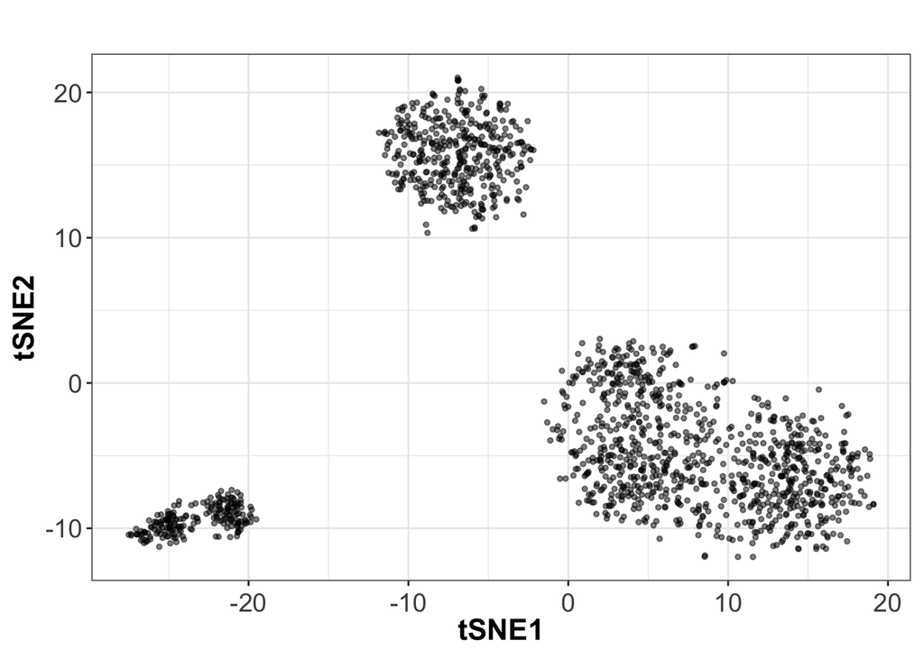

```r
# ========= visualization toolkits =========
# ---  tsne plot ---
graph_data <- graph_data_list$Denitrification_vs_Nitritation
ggplot(graph_data,aes(tSNE1,tSNE2)) +  # ,colour = degs
  geom_point(alpha = 0.5, size = 1) +
  labs(title = '') +
  theme_bw() +
  scale_colour_manual(values = pale_25) +
  mytheme1
```

### ‘M’: Model - Geometric deep learning through DGL algorithm

```bash
cd ./scr
source /Users/yangliao/opt/anaconda3/bin/activate pyg
# conda activate pyg

#!/bin/sh
dataset_name='JS_18samples_metagenomics' # dataset
group='Denitrification_vs_Nitritation' # subdataset
threshold=0.2 # threshold for edge construction
epoch=20000 # trainnning epoches

# To run graph learning, un-annotated the following commands:
# python3 -c "import main; main.set_config('$dataset_name', '$group', thre=$threshold, num_epoch=$epoch); print(main.config['data_path']); main.main()"
```

```
../data/JS_18samples_metagenomics/inputdata/dgidata_Denitrification_vs_Nitritation.csv
feature shape:  (6, 1521)
cuda is not available
Threshold: 0.2
 Links number: 34673
 Average Links: 22.79618671926364
Adj: (1521, 1521) Edges: 34673
X: (1521, 6)
Adj: (1521, 1521) Edges: 34673
X: (1521, 6)
-----------Deep Graph Infomax-------------
Epoch: 100, Loss: 1.3575
Epoch: 200, Loss: 1.3132
Epoch: 300, Loss: 1.2762
Epoch: 400, Loss: 1.2551
Epoch: 500, Loss: 1.2447
Epoch: 600, Loss: 1.2348
Epoch: 700, Loss: 1.2149
Epoch: 800, Loss: 1.2011
Epoch: 900, Loss: 1.1901
Epoch: 1000, Loss: 1.1849
Epoch: 1100, Loss: 1.1664
Epoch: 1200, Loss: 1.1457
Epoch: 1300, Loss: 1.1265
Epoch: 1400, Loss: 1.1031
Epoch: 1500, Loss: 1.0794
Epoch: 1600, Loss: 1.0689
Epoch: 1700, Loss: 1.0455
Epoch: 1800, Loss: 1.0237
Epoch: 1900, Loss: 0.9931
Epoch: 2000, Loss: 0.9848
Epoch: 2100, Loss: 0.9414
Epoch: 2200, Loss: 0.9278
Epoch: 2300, Loss: 0.8837
Epoch: 2400, Loss: 0.8639
Epoch: 2500, Loss: 0.8409
Epoch: 2600, Loss: 0.8513
Epoch: 2700, Loss: 0.7758
Epoch: 2800, Loss: 0.7793
Epoch: 2900, Loss: 0.7914
Epoch: 3000, Loss: 0.7050
Epoch: 3100, Loss: 0.7104
Epoch: 3200, Loss: 0.6737
Epoch: 3300, Loss: 0.6719
Epoch: 3400, Loss: 0.6464
Epoch: 3500, Loss: 0.6641
Epoch: 3600, Loss: 0.6758
Epoch: 3700, Loss: 0.5641
Epoch: 3800, Loss: 0.5795
Epoch: 3900, Loss: 0.5807
Epoch: 4000, Loss: 0.5045
Epoch: 4100, Loss: 0.5093
Epoch: 4200, Loss: 0.5539
Epoch: 4300, Loss: 0.4655
Epoch: 4400, Loss: 0.5006
Epoch: 4500, Loss: 0.5557
Epoch: 4600, Loss: 0.4323
Epoch: 4700, Loss: 0.4549
Epoch: 4800, Loss: 0.4750
Epoch: 4900, Loss: 0.4424
Epoch: 5000, Loss: 0.4632
Epoch: 5100, Loss: 0.4584
Epoch: 5200, Loss: 0.4821
Epoch: 5300, Loss: 0.3726
Epoch: 5400, Loss: 0.4252
Epoch: 5500, Loss: 0.4100
Epoch: 5600, Loss: 0.4233
Epoch: 5700, Loss: 0.3961
Epoch: 5800, Loss: 0.4642
Epoch: 5900, Loss: 0.4187
Epoch: 6000, Loss: 0.4850
Epoch: 6100, Loss: 0.3898
Epoch: 6200, Loss: 0.3856
Epoch: 6300, Loss: 0.3829
Epoch: 6400, Loss: 0.3681
Epoch: 6500, Loss: 0.3784
Epoch: 6600, Loss: 0.3670
Epoch: 6700, Loss: 0.3688
Epoch: 6800, Loss: 0.3838
Epoch: 6900, Loss: 0.4362
Epoch: 7000, Loss: 0.3303
Epoch: 7100, Loss: 0.4051
Epoch: 7200, Loss: 0.3227
Epoch: 7300, Loss: 0.3035
Epoch: 7400, Loss: 0.3400
Epoch: 7500, Loss: 0.3904
Epoch: 7600, Loss: 0.3690
Epoch: 7700, Loss: 0.3876
Epoch: 7800, Loss: 0.3692
Epoch: 7900, Loss: 0.3276
Epoch: 8000, Loss: 0.3276
Epoch: 8100, Loss: 0.3419
Epoch: 8200, Loss: 0.2983
Epoch: 8300, Loss: 0.3225
Epoch: 8400, Loss: 0.3406
Epoch: 8500, Loss: 0.3985
Epoch: 8600, Loss: 0.3467
Epoch: 8700, Loss: 0.3264
Epoch: 8800, Loss: 0.2713
Epoch: 8900, Loss: 0.3888
Epoch: 9000, Loss: 0.3278
Epoch: 9100, Loss: 0.3610
Epoch: 9200, Loss: 0.3036
Epoch: 9300, Loss: 0.3213
Epoch: 9400, Loss: 0.3381
Epoch: 9500, Loss: 0.3125
Epoch: 9600, Loss: 0.3134
Epoch: 9700, Loss: 0.3757
Epoch: 9800, Loss: 0.3189
Epoch: 9900, Loss: 0.4771
Epoch: 10000, Loss: 0.4083
Epoch: 10100, Loss: 0.3417
Epoch: 10200, Loss: 0.3038
Epoch: 10300, Loss: 0.3384
Epoch: 10400, Loss: 0.3516
Epoch: 10500, Loss: 0.3002
Epoch: 10600, Loss: 0.3621
Epoch: 10700, Loss: 0.3093
Epoch: 10800, Loss: 0.3239
Epoch: 10900, Loss: 0.3876
Epoch: 11000, Loss: 0.4194
Epoch: 11100, Loss: 0.3191
Epoch: 11200, Loss: 0.3540
Epoch: 11300, Loss: 0.2929
Epoch: 11400, Loss: 0.3615
Epoch: 11500, Loss: 0.2921
Epoch: 11600, Loss: 0.3729
Epoch: 11700, Loss: 0.3846
Epoch: 11800, Loss: 0.4322
Epoch: 11900, Loss: 0.2728
Epoch: 12000, Loss: 0.3905
Epoch: 12100, Loss: 0.2819
Epoch: 12200, Loss: 0.3137
Epoch: 12300, Loss: 0.3973
Epoch: 12400, Loss: 0.2676
Epoch: 12500, Loss: 0.3517
Epoch: 12600, Loss: 0.3161
Epoch: 12700, Loss: 0.2965
Epoch: 12800, Loss: 0.3589
Epoch: 12900, Loss: 0.3260
Epoch: 13000, Loss: 0.3278
Epoch: 13100, Loss: 0.3085
Epoch: 13200, Loss: 0.2352
Epoch: 13300, Loss: 0.3299
Epoch: 13400, Loss: 0.3534
Epoch: 13500, Loss: 0.3080
Epoch: 13600, Loss: 0.3209
Epoch: 13700, Loss: 0.2902
Epoch: 13800, Loss: 0.3486
Epoch: 13900, Loss: 0.3334
Epoch: 14000, Loss: 0.2941
Epoch: 14100, Loss: 0.4045
Epoch: 14200, Loss: 0.3128
Epoch: 14300, Loss: 0.3055
Epoch: 14400, Loss: 0.3642
Epoch: 14500, Loss: 0.2739
Epoch: 14600, Loss: 0.3880
Epoch: 14700, Loss: 0.3350
Epoch: 14800, Loss: 0.4435
Epoch: 14900, Loss: 0.3251
Epoch: 15000, Loss: 0.3430
Epoch: 15100, Loss: 0.4501
Epoch: 15200, Loss: 0.2847
Epoch: 15300, Loss: 0.2770
Epoch: 15400, Loss: 0.2761
Epoch: 15500, Loss: 0.3773
Epoch: 15600, Loss: 0.3148
Epoch: 15700, Loss: 0.3512
Epoch: 15800, Loss: 0.3226
Epoch: 15900, Loss: 0.2802
Epoch: 16000, Loss: 0.3776
Epoch: 16100, Loss: 0.2630
Epoch: 16200, Loss: 0.2629
Epoch: 16300, Loss: 0.2752
Epoch: 16400, Loss: 0.3054
Epoch: 16500, Loss: 0.3241
Epoch: 16600, Loss: 0.3927
Epoch: 16700, Loss: 0.3404
Epoch: 16800, Loss: 0.3080
Epoch: 16900, Loss: 0.3264
Epoch: 17000, Loss: 0.2587
Epoch: 17100, Loss: 0.3063
Epoch: 17200, Loss: 0.2688
Epoch: 17300, Loss: 0.3328
Epoch: 17400, Loss: 0.3143
Epoch: 17500, Loss: 0.3569
Epoch: 17600, Loss: 0.2469
Epoch: 17700, Loss: 0.3811
Epoch: 17800, Loss: 0.3875
Epoch: 17900, Loss: 0.3625
Epoch: 18000, Loss: 0.2924
Epoch: 18100, Loss: 0.2910
Epoch: 18200, Loss: 0.2894
Epoch: 18300, Loss: 0.3221
Epoch: 18400, Loss: 0.3685
Epoch: 18500, Loss: 0.3164
Epoch: 18600, Loss: 0.3426
Epoch: 18700, Loss: 0.2595
Epoch: 18800, Loss: 0.2788
Epoch: 18900, Loss: 0.3000
Epoch: 19000, Loss: 0.3577
Epoch: 19100, Loss: 0.3206
Epoch: 19200, Loss: 0.3255
Epoch: 19300, Loss: 0.3878
Epoch: 19400, Loss: 0.3575
Epoch: 19500, Loss: 0.3323
Epoch: 19600, Loss: 0.3028
Epoch: 19700, Loss: 0.3125
Epoch: 19800, Loss: 0.3770
Epoch: 19900, Loss: 0.2760
Epoch: 20000, Loss: 0.3009
Training time in seconds:  3008
-----------Clustering-------------
Shape of data to PCA: (1521, 256)
Shape of data output by PCA: (1521, 30)
PCA recover: 0.99999946
Shape of data to cluster: (1521, 30)
SCI score (Clustering quality) is: 0.6572211
```